# nbaTools Package Exploration

Basketball Fanalyst

5/16/2018

```r
knitr::opts_chunk$set(echo = TRUE)
library(nbaTools)
library(tidyverse)
library(lubridate)
library(ggrepel)
library(RColorBrewer)

testgameid <- "0041700302" # Game 2 of the ECF (5/15/2018), BOS 104-97 CLE
testplayerid <- "1628369"  # Jayson Tatum
```

# Source Code

The [source code](https://github.com/ccagrawal/nbaTools) is an important reference, because it allows us find the available parameters and defaults for each function.

### HTTP Headers

The source code will make more sense with a basic understanding of HTTP. [HTTP Headers for Dummies](https://code.tutsplus.com/tutorials/http-headers-for-dummies--net-8039) is a useful and concise explanation.

### GetPlayerHustleStats example

Take the **GetPlayerHustleStats** function as an example. We don’t know the available parameters for this function or their default values. We also do not know the definitions of the data; what does ‘15 contested shots’ mean? Is that in one season? One game? Per 36 minutes? Let’s explore the source code to answer these question:

- We go to the [source code](https://github.com/ccagrawal/nbaTools) and navigate to the [/R directory](https://github.com/ccagrawal/nbaTools/tree/master/R). It’s not clear which script contains the definition of **GetPlayerHustleStats**, so we search for *hustle* and find that **GetPlayerHustleStats** is defined in league_scrape.R
- **GetPlayerHustleStats** defines some parameters and then returns a function **GetData** that we will investigate next, but first let’s understand the parameters defined in **GetPlayerHustleStats** and passed to **GetData**:
  1. `endpoint <- 'leaguehustlestatsplayer'`
     - The endpoint is used in determining the URL. We can try to manually generate the request in a browser: https://stats.nba.com/stats/leaguehustlestatsplayer. We will get an error indicating that we are missing some required parameters: “The LeagueID property is required.; Season is required; SeasonType is required; PerMode is required”. Default values are defined for these somewhere in the code, more on this later.
  2. `referer <- 'players/hustle'`
     - The referer is an HTTP header that indicates the source of this request. For example, if we click a link on espn.com, that will generate an HTTP request with a header like `referer: www.espn.com`.
     - So what does ‘players/hustle’ mean as the HTTP referer here? More on this when we find default values.
  3. `ix <- 1`
     - ‘ix’ probably stands for ‘index’. It is used to determine the position of the desired content in the list returned by **ScrapeContent** (see below).
  4. `param.keys`
     - This is a list of the parameters that can be passed to the guery in the HTTP GET request. It is important to know what the default values are for these.
  5. Also notice that `source = "NBA"` is passed as a parameter. This package scrapes from multiple sites (e.g. nba.com, basketball-reference), and some functions behave differently depending on the source website. **GetPlayerHustleStats** is a simple example as hustle stats are only available at stats.NBA.com.
- Now that we understand the parameters, let’s figure out the function that they get passed to: **GetData**. The defnition is found in scrape.R. This function has 3 basic steps:
  1. `params <- GenerateParams(param.keys, source, ...)`
     - This function creates a list of key-value pairs by looping through the param.keys and finding their default value in *kDefaultParams* from constants.R. It then replaces those default values with any values explicitly provided in the function call (the kwargs). Looking at the list *kDefaultParams* shows us the default values provided for our 4 required parameters
       - `LeagueID = '00'`
       - `Season = kSeason # kYear <- CurrentYear(); kSeason <- YearToSeason(kYear)` This will result in ‘2017-18’
       - `SeasonType = 'Regular Season'`
       - `PerMode = 'PerGame'`
     - Let’s add these defaults as parameter values and try again to manually make the HTTP request in a browser: https://stats.nba.com/stats/leaguehustlestatsplayer?LeagueID=00&Season=2017-18&SeasonType=Regular%20Season&PerMode=PerGame. Success!
  2. `content <- ScrapeContent(endpoint, params, referer, source)`
     - Uses the httr package to scrape for data. We are combining our defaults with the information passed by the user and making an HTTP GET request.
     - This is also where the *referer* gets used. We can see that **ScrapeContent** loads the defaults in *kHeaders* which includes `'Referer' = 'http://stats.nba.com/%referer%/',`. We then substitute in our *referer* value of ‘players/hustle’ resulting in a referer url of http://stats.nba.com/players/hustle/.
     - Our manually generated URL above generates the same HTTP GET request as **ScrapeContent** except that it has no referer value. **It’s unclear how the spoofed referer impacts the results of the request compared to having no referer**.
  3. `df <- ContentToDataFrame(content, ix, source)`
     - Finally, we take the returned data and convert it to a data frame. This df is returned as the final result of **GetPlayerHustleStats**.
     - Note: This function contains some if logic based on the *source* that determines how to use *ix* to extract the desired results from the *content* returned by **ScrapeContent**.

```r
as.tibble(GetPlayerHustleStats())
```

```
## # A tibble: 540 x 15
##    PLAYER_ID PLAYER_NAME     TEAM_ID    TEAM_ABBREVIATI…   AGE     G   MIN
##    <chr>     <chr>           <chr>      <chr>            <int> <int> <int>
##  1 201166    Aaron Brooks    1610612750 MIN                 33    32     6
##  2 203932    Aaron Gordon    1610612753 ORL                 22    58    33
##  3 1626151   Aaron Harrison  1610612742 DAL                 23     9    26
##  4 1628935   Aaron Jackson   1610612745 HOU                 32     1    35
##  5 1627846   Abdel Nader     1610612738 BOS                 24    48    11
##  6 203940    Adreian Payne   1610612753 ORL                 27     5     9
##  7 201143    Al Horford      1610612738 BOS                 31    72    32
##  8 2744      Al Jefferson    1610612754 IND                 33    36    13
##  9 202329    Al-Farouq Aminu 1610612757 POR                 27    69    30
## 10 1626210   Alan Williams   1610612756 PHX                 25     5    14
## # ... with 530 more rows, and 8 more variables: CONTESTED_SHOTS <dbl>,
## #   CONTESTED_SHOTS_2PT <dbl>, CONTESTED_SHOTS_3PT <dbl>,
## #   CHARGES_DRAWN <dbl>, DEFLECTIONS <dbl>, LOOSE_BALLS_RECOVERED <dbl>,
## #   SCREEN_ASSISTS <dbl>, BOX_OUTS <dbl>
```

# Functions

This package has a 28 functions with help pages in documentation. The first goal here is to explore those functions and see what kind of data we get back. The functions are inconsistent in names and required variables, so I’ll go through them manually to understand them.

**GetBoxScore** gets basic box stats from stats.nba.com. It gives play time to the second (at least for recent games). Note that there is a player_id column that stats.nba probably uses to index all players. We have some fun with ggplot to show some of this data

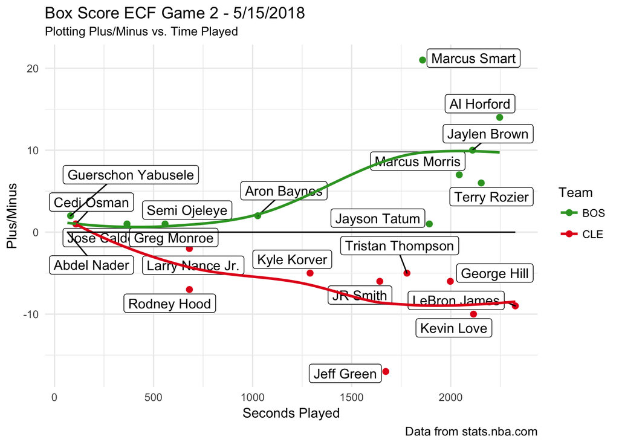

```r
boxscore <- as.tibble(GetBoxScore(GameID = testgameid))
boxscore %>%
  ggplot(aes(x = as.numeric(ms(MIN)), y = PLUS_MINUS)) +
    geom_point(aes(color = TEAM_ABBREVIATION), size = 2) +
    ggrepel::geom_label_repel(
      aes(label = PLAYER_NAME)
    ) +
    geom_smooth(aes(color = TEAM_ABBREVIATION), se = FALSE) +
    labs(
      y = "Plus/Minus",
      x = "Seconds Played",
      title = "Box Score ECF Game 2 - 5/15/2018",
      subtitle = "Plotting Plus/Minus vs. Time Played",
      color = "Team",
      caption = "Data from stats.nba.com"
    ) +
    scale_color_manual(
      values = c(BOS = "#33A02C", CLE = "#E41A1C")
    ) +
    geom_line(y = 0, color = "black") +
    theme_minimal()
```

**GetGameLogs** returns a record for each game a player played in, with their box stats for that game

**GetGames** takes a date variable and returns a list of game_ids for that date

**GetLineups** gets the play-by-play and includes the IDs of all 10 players on the floor for each event. This is potentially a very powerful dataset, could be used to model probabilities based on matchups. There are numerous descriptive columns, but it seems that EVENTMSGTYPE and EVENTMSGACTIONTYPE are the key indicator fields that would need to be decoded for this data to make sense. We will need to decipher these codes and build a mapping to something readable.

```r
lineups <- as.tibble(GetLineups(testgameid))
lineups
```

```
## # A tibble: 448 x 43
##    GAME_ID    EVENTNUM EVENTMSGTYPE EVENTMSGACTIONTYPE PERIOD WCTIMESTRING
##  * <chr>         <int>        <int>              <int>  <int> <chr>
##  1 0041700302        2           12                  0      1 8:41 PM
##  2 0041700302        4           10                  0      1 8:41 PM
##  3 0041700302        7            5                 45      1 8:41 PM
##  4 0041700302        8            1                  1      1 8:42 PM
##  5 0041700302       10            2                 98      1 8:42 PM
##  6 0041700302       11            4                  0      1 8:42 PM
##  7 0041700302       12            1                 97      1 8:42 PM
##  8 0041700302       13            5                 45      1 8:42 PM
##  9 0041700302       14            1                  6      1 8:43 PM
## 10 0041700302       15            2                  1      1 8:43 PM
## # ... with 438 more rows, and 37 more variables: PCTIMESTRING <chr>,
## #   HOMEDESCRIPTION <chr>, NEUTRALDESCRIPTION <lgl>,
## #   VISITORDESCRIPTION <chr>, SCORE <chr>, SCOREMARGIN <chr>,
## #   PERSON1TYPE <int>, PLAYER1_ID <chr>, PLAYER1_NAME <chr>,
## #   PLAYER1_TEAM_ID <chr>, PLAYER1_TEAM_CITY <chr>,
## #   PLAYER1_TEAM_NICKNAME <chr>, PLAYER1_TEAM_ABBREVIATION <chr>,
## #   PERSON2TYPE <int>, PLAYER2_ID <chr>, PLAYER2_NAME <chr>,
## #   PLAYER2_TEAM_ID <chr>, PLAYER2_TEAM_CITY <chr>,
## #   PLAYER2_TEAM_NICKNAME <chr>, PLAYER2_TEAM_ABBREVIATION <chr>,
## #   PERSON3TYPE <int>, PLAYER3_ID <chr>, PLAYER3_NAME <chr>,
## #   PLAYER3_TEAM_ID <chr>, PLAYER3_TEAM_CITY <chr>,
## #   PLAYER3_TEAM_NICKNAME <chr>, PLAYER3_TEAM_ABBREVIATION <chr>,
## #   H1 <chr>, H2 <chr>, H3 <chr>, H4 <chr>, H5 <chr>, A1 <chr>, A2 <chr>,
## #   A3 <chr>, A4 <chr>, A5 <chr>
```

```r
eventmsgtype_sum <- lineups %>%
  group_by(EVENTMSGTYPE) %>%
  summarize(count = n())
eventmsgtype_sum
```

```
## # A tibble: 11 x 2
##    EVENTMSGTYPE count
##           <int> <int>
##  1            1    77
##  2            2    95
##  3            3    37
##  4            4   105
##  5            5    21
##  6            6    41
##  7            8    51
##  8            9    10
##  9           10     3
## 10           12     4
## 11           13     4
```

```r
eventmsgactiontype_sum <- lineups %>%
  group_by(EVENTMSGACTIONTYPE) %>%
  summarize(count = n())
eventmsgactiontype_sum
```

```
## # A tibble: 43 x 2
##    EVENTMSGACTIONTYPE count
##                 <int> <int>
##  1                  0   162
##  2                  1    82
##  3                  2    23
##  4                  3     2
##  5                  4     2
##  6                  5     1
##  7                  6    13
##  8                  9     1
##  9                 10     7
## 10                 11    15
## # ... with 33 more rows
```

**GetLineupStats** returns a record with accumulated stats for each grouping of 5 players. This is a summarized version of GetLineups that ignores the opponent’s lineup

**GetPlayByPlay** seems to be the same as GetLineups but without the 10 player_ids attached to every event.

**GetPlayerBioStats** returns stuff like age, height, weight, draft status, college, nationality

**GetPlayerClutchStats** returns pretty standard player stats where the default value for clutch is ‘last 5 minutes’

**GetPlayerDefenseStats** doesn’t have very many variables, and they don’t seem promising

**GetPlayerGameLogs** seems redundant with GetGameLogs

**GetPlayerHustleStats** has some player level summaries of interesting data points such as contested shots, charges drawn, deflections, loose balls recovered, screen assists, box outs. Default is per-game stats.

```
## [[1]]
## [[1]][[1]]
## # A tibble: 10 x 3
##    PLAYER_NAME        statistic       value
##    <chr>              <chr>           <dbl>
##  1 Rudy Gobert        CONTESTED_SHOTS  15.0
##  2 Karl-Anthony Towns CONTESTED_SHOTS  14.4
##  3 Anthony Davis      CONTESTED_SHOTS  14.2
##  4 Kristaps Porzingis CONTESTED_SHOTS  13.6
##  5 Steven Adams       CONTESTED_SHOTS  13.4
##  6 DeMarcus Cousins   CONTESTED_SHOTS  13.3
##  7 Clint Capela       CONTESTED_SHOTS  12.8
##  8 Brook Lopez        CONTESTED_SHOTS  12.6
##  9 Nikola Jokic       CONTESTED_SHOTS  12.6
## 10 LaMarcus Aldridge  CONTESTED_SHOTS  12.5
##
## [[1]][[2]]
```

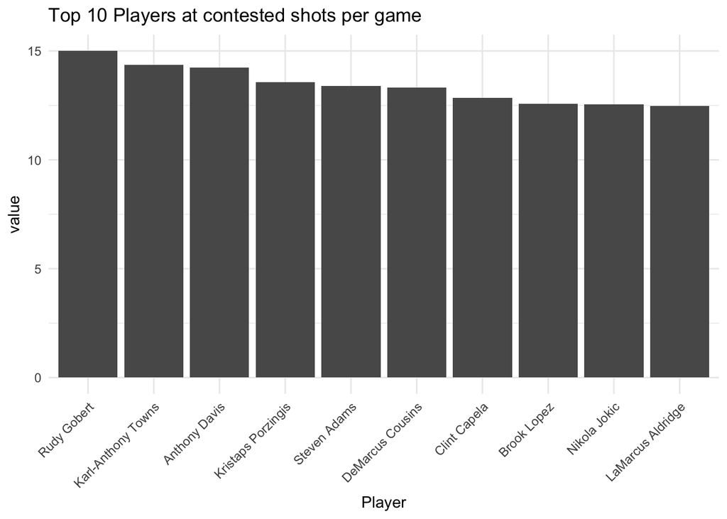

```
##
##
## [[2]]
## [[2]][[1]]
## # A tibble: 10 x 3
##    PLAYER_NAME        statistic           value
##    <chr>              <chr>               <dbl>
##  1 Rudy Gobert        CONTESTED_SHOTS_2PT 12.7
##  2 Karl-Anthony Towns CONTESTED_SHOTS_2PT 11.4
##  3 DeMarcus Cousins   CONTESTED_SHOTS_2PT 10.6
##  4 Clint Capela       CONTESTED_SHOTS_2PT 10.3
##  5 Brook Lopez        CONTESTED_SHOTS_2PT 10.1
##  6 LaMarcus Aldridge  CONTESTED_SHOTS_2PT  9.92
##  7 Jonas Valanciunas  CONTESTED_SHOTS_2PT  9.81
##  8 Anthony Davis      CONTESTED_SHOTS_2PT  9.80
##  9 Jusuf Nurkic       CONTESTED_SHOTS_2PT  9.80
## 10 Jarrett Allen      CONTESTED_SHOTS_2PT  9.64
##
## [[2]][[2]]
```

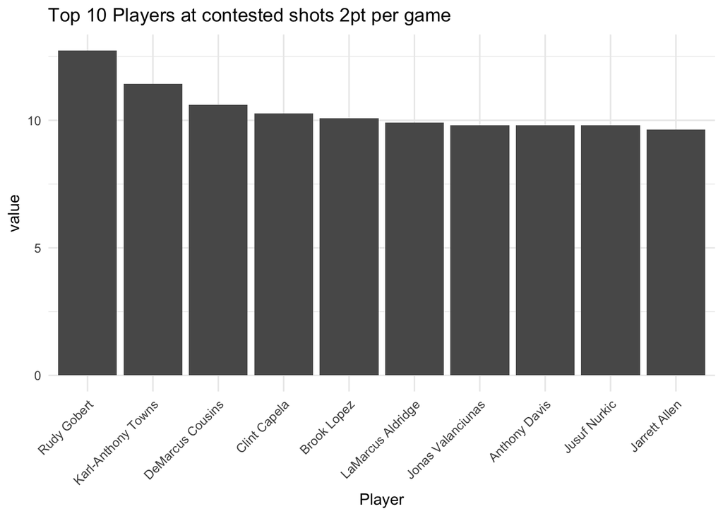

```
##
##
## [[3]]
## [[3]][[1]]
## # A tibble: 12 x 3
##    PLAYER_NAME        statistic           value
##    <chr>              <chr>               <dbl>
##  1 Victor Oladipo     CONTESTED_SHOTS_3PT  4.75
##  2 Andrew Wiggins     CONTESTED_SHOTS_3PT  4.72
##  3 Thaddeus Young     CONTESTED_SHOTS_3PT  4.67
##  4 Anthony Davis      CONTESTED_SHOTS_3PT  4.43
##  5 Jrue Holiday       CONTESTED_SHOTS_3PT  4.28
##  6 Brandon Ingram     CONTESTED_SHOTS_3PT  4.22
##  7 Kristaps Porzingis CONTESTED_SHOTS_3PT  4.21
##  8 Taj Gibson         CONTESTED_SHOTS_3PT  4.18
##  9 Bradley Beal       CONTESTED_SHOTS_3PT  4.12
## 10 Andre Ingram       CONTESTED_SHOTS_3PT  4.00
## 11 Luol Deng          CONTESTED_SHOTS_3PT  4.00
## 12 Marquis Teague     CONTESTED_SHOTS_3PT  4.00
##
## [[3]][[2]]
```

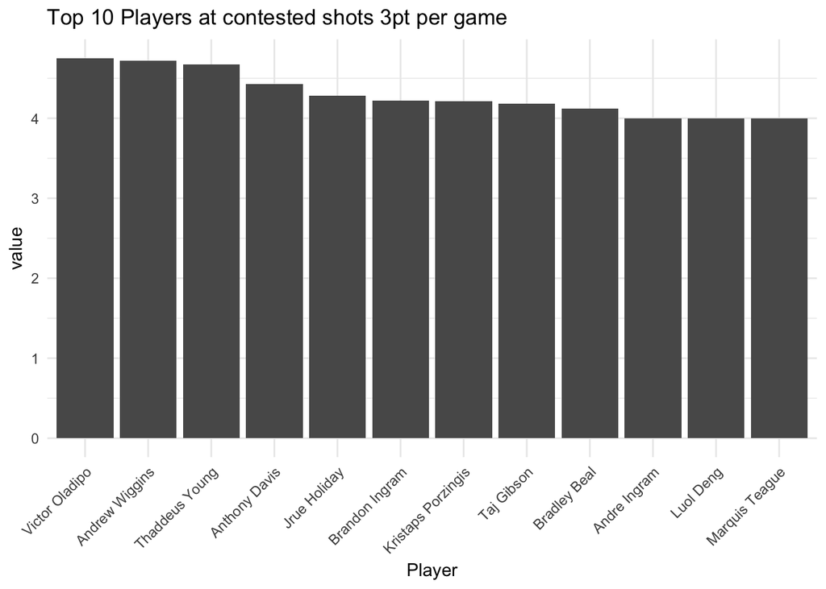

```
##
##
## [[4]]
## [[4]][[1]]
## # A tibble: 10 x 3
##    PLAYER_NAME       statistic     value
##    <chr>             <chr>         <dbl>
##  1 Andre Ingram      CHARGES_DRAWN 1.00
##  2 Devin Robinson    CHARGES_DRAWN 1.00
##  3 DeMarcus Cousins  CHARGES_DRAWN 0.500
##  4 Kyle Lowry        CHARGES_DRAWN 0.470
##  5 Ersan Ilyasova    CHARGES_DRAWN 0.460
##  6 Patrick Beverley  CHARGES_DRAWN 0.450
##  7 Marreese Speights CHARGES_DRAWN 0.370
##  8 Okaro White       CHARGES_DRAWN 0.330
##  9 Kemba Walker      CHARGES_DRAWN 0.300
## 10 Quincy Acy        CHARGES_DRAWN 0.300
##
## [[4]][[2]]
```

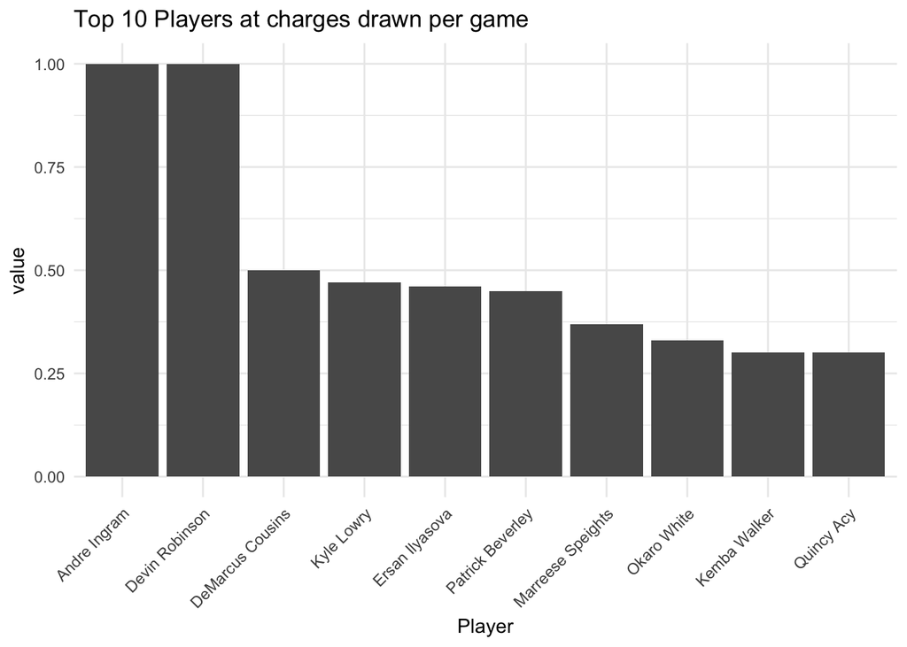

```
##
##
## [[5]]
## [[5]][[1]]
## # A tibble: 10 x 3
##    PLAYER_NAME       statistic   value
##    <chr>             <chr>       <dbl>
##  1 Aaron Jackson     DEFLECTIONS  4.00
##  2 Robert Covington  DEFLECTIONS  3.90
##  3 Paul George       DEFLECTIONS  3.87
##  4 Victor Oladipo    DEFLECTIONS  3.73
##  5 Thaddeus Young    DEFLECTIONS  3.56
##  6 Jimmy Butler      DEFLECTIONS  3.47
##  7 Eric Bledsoe      DEFLECTIONS  3.34
##  8 Russell Westbrook DEFLECTIONS  3.31
##  9 Andre Drummond    DEFLECTIONS  3.18
## 10 Kris Dunn         DEFLECTIONS  3.13
##
## [[5]][[2]]
```

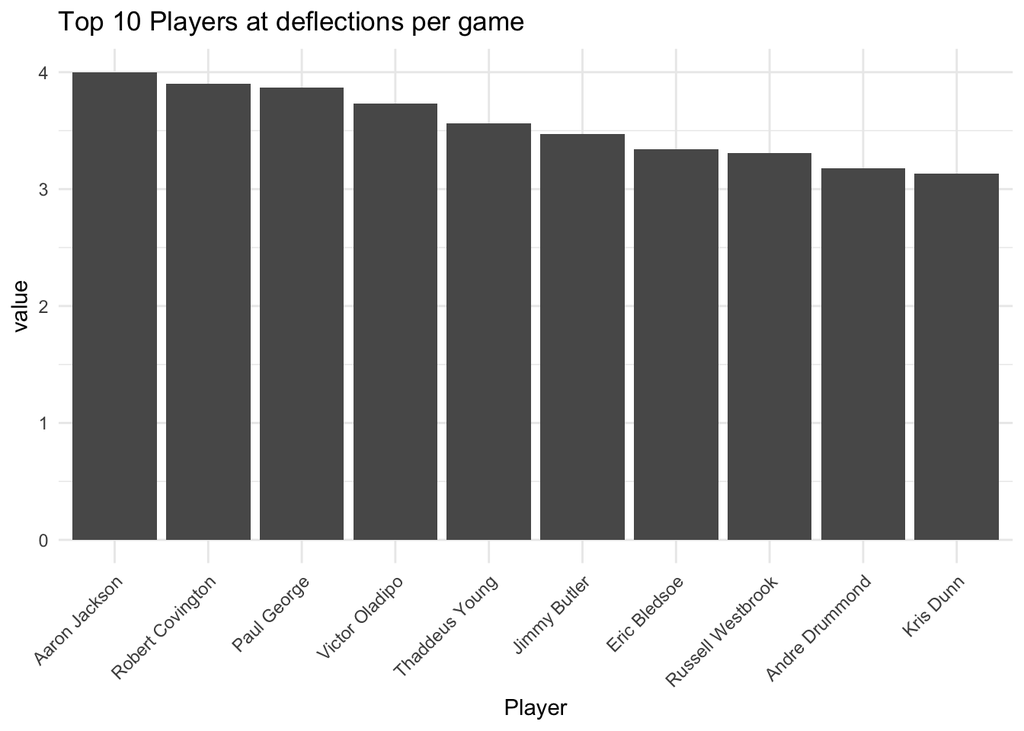

```
##
##
## [[6]]
## [[6]][[1]]
## # A tibble: 10 x 3
##    PLAYER_NAME           statistic             value
##    <chr>                 <chr>                 <dbl>
##  1 Russell Westbrook     LOOSE_BALLS_RECOVERED  2.18
##  2 Jimmy Butler          LOOSE_BALLS_RECOVERED  1.92
##  3 Patrick Beverley      LOOSE_BALLS_RECOVERED  1.91
##  4 Ben Simmons           LOOSE_BALLS_RECOVERED  1.77
##  5 Paul George           LOOSE_BALLS_RECOVERED  1.77
##  6 Giannis Antetokounmpo LOOSE_BALLS_RECOVERED  1.73
##  7 Jrue Holiday          LOOSE_BALLS_RECOVERED  1.63
##  8 Stephen Curry         LOOSE_BALLS_RECOVERED  1.63
##  9 Damian Lillard        LOOSE_BALLS_RECOVERED  1.62
## 10 DeMarcus Cousins      LOOSE_BALLS_RECOVERED  1.58
##
## [[6]][[2]]
```

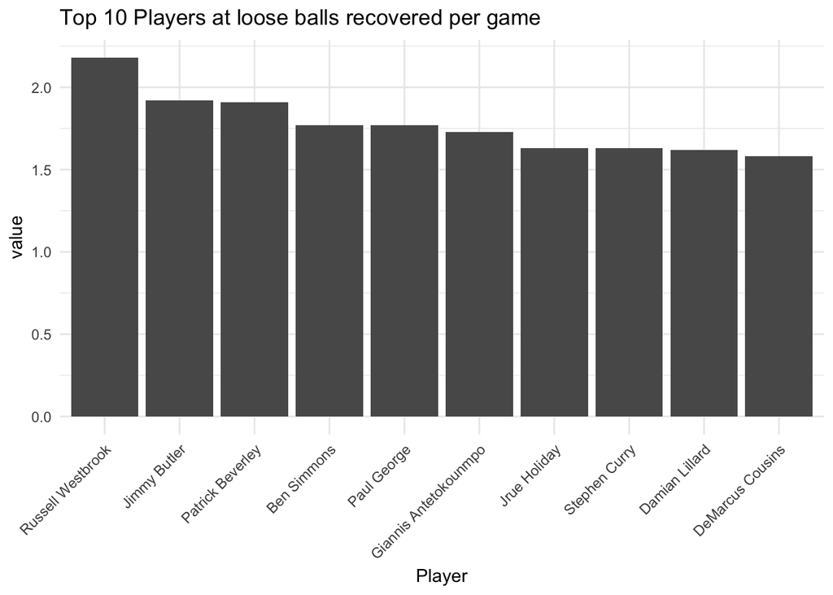

```
##
##
## [[7]]
## [[7]][[1]]
## # A tibble: 10 x 3
##    PLAYER_NAME    statistic      value
##    <chr>          <chr>          <dbl>
##  1 Rudy Gobert    SCREEN_ASSISTS  6.18
##  2 Steven Adams   SCREEN_ASSISTS  4.80
##  3 Andre Drummond SCREEN_ASSISTS  4.67
##  4 Marcin Gortat  SCREEN_ASSISTS  4.45
##  5 Nikola Jokic   SCREEN_ASSISTS  4.25
##  6 Dwight Howard  SCREEN_ASSISTS  4.17
##  7 Robin Lopez    SCREEN_ASSISTS  4.09
##  8 Myles Turner   SCREEN_ASSISTS  3.97
##  9 Tyson Chandler SCREEN_ASSISTS  3.93
## 10 DeAndre Jordan SCREEN_ASSISTS  3.92
##
## [[7]][[2]]
```

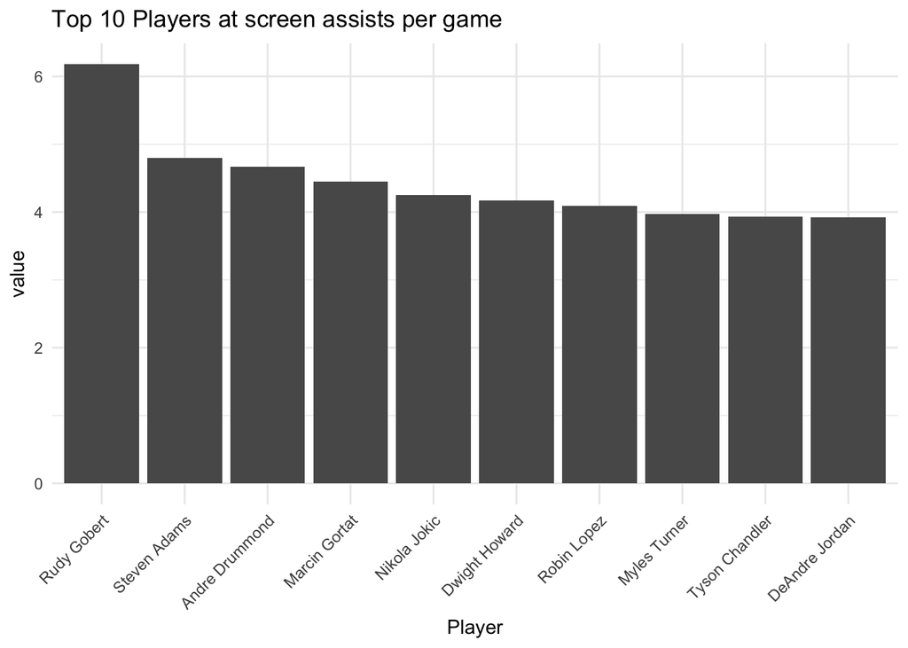

```
##
##
## [[8]]
## [[8]][[1]]
## # A tibble: 10 x 3
##    PLAYER_NAME       statistic value
##    <chr>             <chr>     <dbl>
##  1 Steven Adams      BOX_OUTS  11.6
##  2 Enes Kanter       BOX_OUTS  10.1
##  3 DeAndre Jordan    BOX_OUTS   9.30
##  4 LaMarcus Aldridge BOX_OUTS   9.23
##  5 Andre Drummond    BOX_OUTS   8.94
##  6 Robin Lopez       BOX_OUTS   8.94
##  7 Ed Davis          BOX_OUTS   8.88
##  8 Jusuf Nurkic      BOX_OUTS   8.56
##  9 Rudy Gobert       BOX_OUTS   8.55
## 10 Myles Turner      BOX_OUTS   8.48
##
## [[8]][[2]]
```

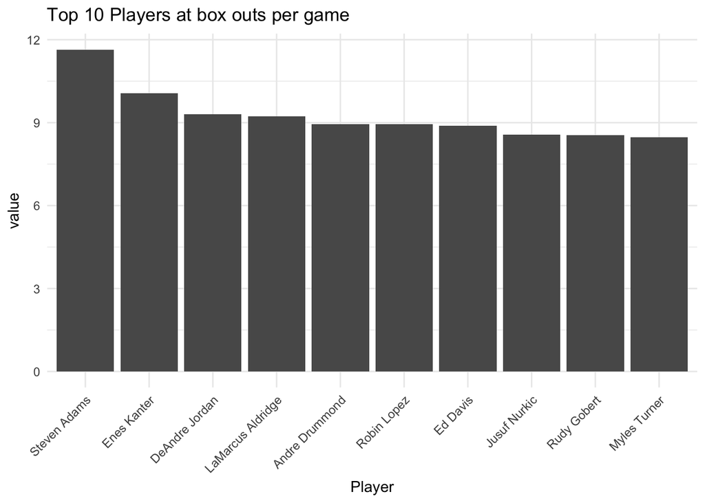

```r
playerhustlestats <- as.tibble(GetPlayerHustleStats(seasonType = "Regular", PerMode = "PerGame"))


#Cheap function mapping to get a nice dataset for plotting
reorder_size <- function(x) {
  factor(x, levels = names(sort(table(x))))
}

getleaders <- function(stat, topn = 10) {
  df <- playerhustlestats %>%
    mutate_(value = stat) %>%
    mutate(statistic = stat) %>%
    select(PLAYER_NAME, statistic, value) %>%
    top_n(topn, value) %>%
    arrange(desc(value))

  plot <-
    ggplot(
       df,
       aes(x = reorder(PLAYER_NAME, -value), y = value)) +
    geom_col() +
    labs(
      x = "Player",
      title = paste0(
        "Top 10 Players at ", str_replace_all( str_to_lower(stat), fixed("_"), " "), " per game"
        )
    ) +
    theme_minimal() +
    theme(axis.text.x = element_text(angle = 45, hjust = 1))

   list(df, plot)
}

# List of stats that we want to get top 10 leaders for
statlist <- c(
  "CONTESTED_SHOTS",
  "CONTESTED_SHOTS_2PT",
  "CONTESTED_SHOTS_3PT",
  "CHARGES_DRAWN",
  "DEFLECTIONS",
  "LOOSE_BALLS_RECOVERED",
  "SCREEN_ASSISTS",
  "BOX_OUTS"
)

out <- map(statlist, getleaders)

out
```

**GetPlayerIDs** returns a list of all player_ids with names and years played

**GetPlayerShootingStats** gives a player level summary of basic shooting stats

**GetPlayerStats** gives basic summary stats for all players in a season

**GetPlayerYearByYearStats** gives very basic yearly stats, there’s not a lot here

**GetPlayTypeStats** Promising! Returns accumulated statistics for teams and players for each play type. Some notes:

- The variables *FT*, *TO*, *SF*, *PlusOne*, and *Score* contain percentages (they should be divided by 100). So a value of 19.72 in FT indicates that 19.72% of these possessions resulted in free throws (or Turnover, Shooting Foul, And 1, any score).
- The *Time* variable is called “Frequency” on the website. This is also a percentage indicating the percentage of this player’s (or team’s) total plays that were of this type. Harden has a 35.1 value for Isolation: 35.1% of his plays were isolations!
- [Nylon Calculus article](https://fansided.com/2017/09/08/nylon-calculus-understanding-synergy-play-type-data/) on the play types
- Note: I found the possible play types (called ‘category’ in the code) [here](https://github.com/ccagrawal/sportsTools/blob/90074b81f20b8b228a3b9ae5e3535084718edb61/R/GetSynergyStats.R). This is a very similar package by the same authoer but older, less polished, and more general. It may be a useful reference.

```r
playtypestats <- as.tibble(GetPlayTypeStats(category = 'Isolation'))
playtypestats <- arrange(playtypestats, desc(Poss))
playtypestats
```

```
## # A tibble: 417 x 34
##    PlayerIDSID PlayerFirstName PlayerLastName PlayerNumber P     TeamIDSID
##          <int> <chr>           <chr>                 <int> <chr> <chr>
##  1      201935 James           Harden                   13 G     16106127…
##  2        2544 LeBron          James                    23 F     16106127…
##  3      201566 Russell         Westbrook                 0 G     16106127…
##  4      203084 Harrison        Barnes                   40 F     16106127…
##  5      101108 Chris           Paul                      3 G     16106127…
##  6      203081 Damian          Lillard                   0 G     16106127…
##  7      203507 Giannis         Antetokounmpo            34 G-F   16106127…
##  8      201142 Kevin           Durant                   35 F     16106127…
##  9        2546 Carmelo         Anthony                   7 F     16106127…
## 10     1628372 Dennis          Smith Jr.                 1 G     16106127…
## # ... with 407 more rows, and 28 more variables: TeamName <chr>,
## #   TeamNameAbbreviation <chr>, TeamShortName <chr>, GP <int>, Poss <int>,
## #   Time <dbl>, Points <int>, FGA <int>, FGM <int>, PPP <dbl>,
## #   WorsePPP <int>, BetterPPP <int>, PossG <dbl>, PPG <dbl>, FGAG <dbl>,
## #   FGMG <dbl>, FGmG <dbl>, FGm <int>, FG <dbl>, aFG <dbl>, FT <dbl>,
## #   TO <dbl>, SF <dbl>, PlusOne <dbl>, Score <dbl>, name <chr>,
## #   season <int>, seasonType <chr>
```

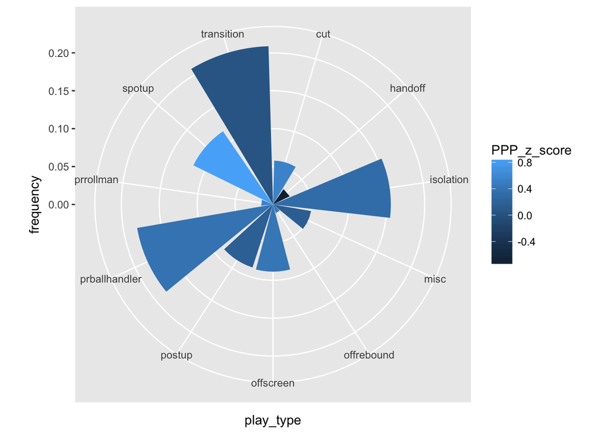

```r
# Took me a while to figure these all out.
play_type_list <- c(
  "transition",
  "isolation",
  "prballhandler",
  "prrollman",
  "postup",
  "spotup",
  "handoff",
  "cut",
  "offscreen",
  "offrebound",
  "misc"
)

# The goal here is a nightengale rose plot, let's manually put this together for jayson tatum first
rate_cols <- c("Time", "FG", "aFG", "FT", "TO", "SF", "PlusOne", "Score")


# ------------------------------------------------------------------------------
# Pull team data
# ------------------------------------------------------------------------------

team_pull <- function (playtype, seasonyr = 2018) {
  as.tibble(GetPlayTypeStats(type = 'team', category = playtype, season = seasonyr)) %>%
    mutate(
      frequency = Time / 100,
      FG_rate = FG / 100,
      eFG_rate = aFG / 100,
      FT_rate = FT / 100,
      TO_rate = TO / 100,
      SF_rate = SF / 100,
      and_one_rate = PlusOne / 100,
      score_rate = Score / 100,
      play_type = playtype
    ) %>%
    select(
      TeamIDSID,
      TeamName,
      TeamNameAbbreviation,
      season,
      play_type,
      Poss,
      Points,
      FGA,
      FGM,
      PPP,
      frequency,
      FG_rate,
      eFG_rate,
      FT_rate,
      TO_rate,
      SF_rate,
      and_one_rate,
      score_rate
    )
}

team_stats <- map(play_type_list, team_pull)
team_stats <- bind_rows(team_stats) %>%
  complete(TeamNameAbbreviation, play_type)

team_stats[is.na(team_stats)] <- 0

# ------------------------------------------------------------------------------
# Aggregate Team data to league
# ------------------------------------------------------------------------------

league_stats <- team_stats %>%
  group_by(play_type) %>%
  summarise(
    Poss = sum(Poss),
    Points = sum(Points),
    PPP = Points / Poss,
    FG_rate = sum(FG_rate * Poss) / sum(Poss),
    eFG_rate = sum(eFG_rate * Poss) / sum(Poss),
    FT_rate = sum(FT_rate * Poss) / sum(Poss),
    TO_rate = sum(TO_rate * Poss) / sum(Poss),
    SF_rate = sum(SF_rate * Poss) / sum(Poss),
    and_one_rate = sum(and_one_rate * Poss) / sum(Poss),
    score_rate = sum(score_rate * Poss) / sum(Poss)
  ) %>%
  mutate(
    frequency = Poss / sum(Poss),
    PPP_score = PPP - mean(PPP)
  )

league_ppp <- sum(league_stats$Points) / sum(league_stats$Poss)

# ------------------------------------------------------------------------------
# Pull player data
# ------------------------------------------------------------------------------

player_pull <- function (playtype, seasonyr = 2018) {
  as.tibble(GetPlayTypeStats(type = 'player', category = playtype, season = seasonyr)) %>%
    mutate(
      frequency = Time / 100,
      FG_rate = FG / 100,
      eFG_rate = aFG / 100,
      FT_rate = FT / 100,
      TO_rate = TO / 100,
      SF_rate = SF / 100,
      and_one_rate = PlusOne / 100,
      score_rate = Score / 100,
      play_type = playtype
    ) %>%
    select(
      PlayerIDSID,
      PlayerFirstName,
      PlayerLastName,
      P,
      TeamIDSID,
      TeamName,
      TeamNameAbbreviation,
      season,
      play_type,
      GP,
      Poss,
      Points,
      FGA,
      FGM,
      PPP,
      frequency,
      FG_rate,
      eFG_rate,
      FT_rate,
      TO_rate,
      SF_rate,
      and_one_rate,
      score_rate
    )
}


player_stats <- map(play_type_list, player_pull)
player_stats <- bind_rows(player_stats) %>%
  complete(PlayerIDSID, play_type)

player_stats[is.na(player_stats)] <- 0

temp_df <- league_stats %>%
  select(play_type,PPP)

player_stats <- player_stats %>%
  inner_join(temp_df, by = "play_type") %>%
  mutate(
    PPP = PPP.x,
    PPP_delta = PPP.x - PPP.y,
    PPP_z_score = (PPP.x - PPP.y) / sd(PPP.x - PPP.y)
    ) %>%
  select(-PPP.x, -PPP.y)

team_stats <- team_stats %>%
  inner_join(temp_df, by = "play_type") %>%
  mutate(
    PPP = PPP.x,
    PPP_delta = PPP.x - PPP.y,
    PPP_z_score = (PPP.x - PPP.y) / sd(PPP.x - PPP.y)
    ) %>%
  select(-PPP.x, -PPP.y)

# ------------------------------------------------------------------------------
# Plots
# ------------------------------------------------------------------------------

rose_plot <- function(df) {
  ggplot(
    df,
    aes(x = play_type,
        y = frequency,
        fill = PPP_z_score
    )
  ) +
  geom_bar(stat = "identity") +
  coord_polar() +
  scale_fill_continuous()
}

rose_plot(player_stats[player_stats$PlayerLastName=="Durant",])
```

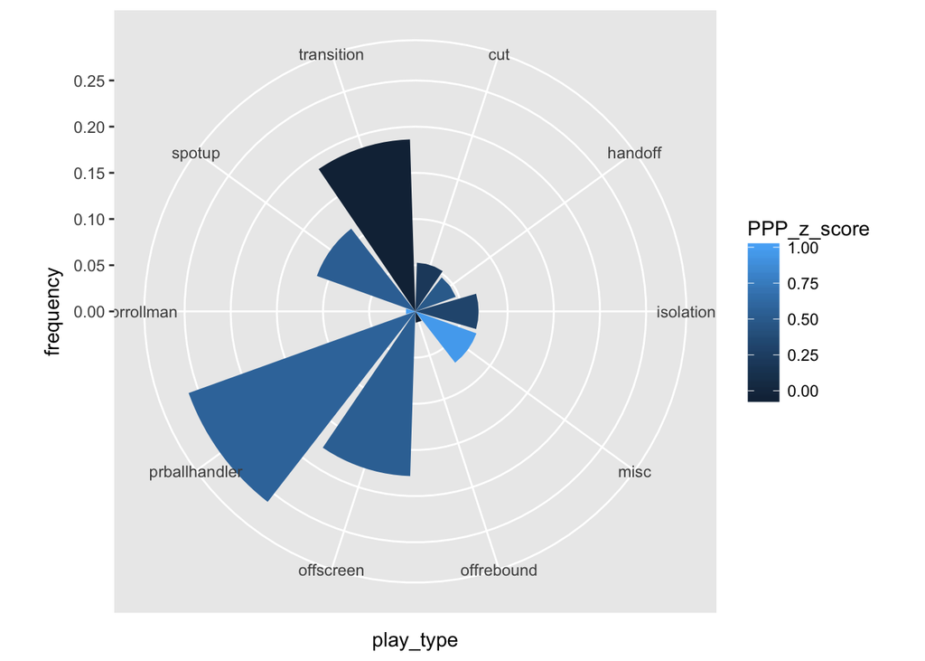

```r
rose_plot(player_stats[player_stats$PlayerLastName=="Curry",])
```

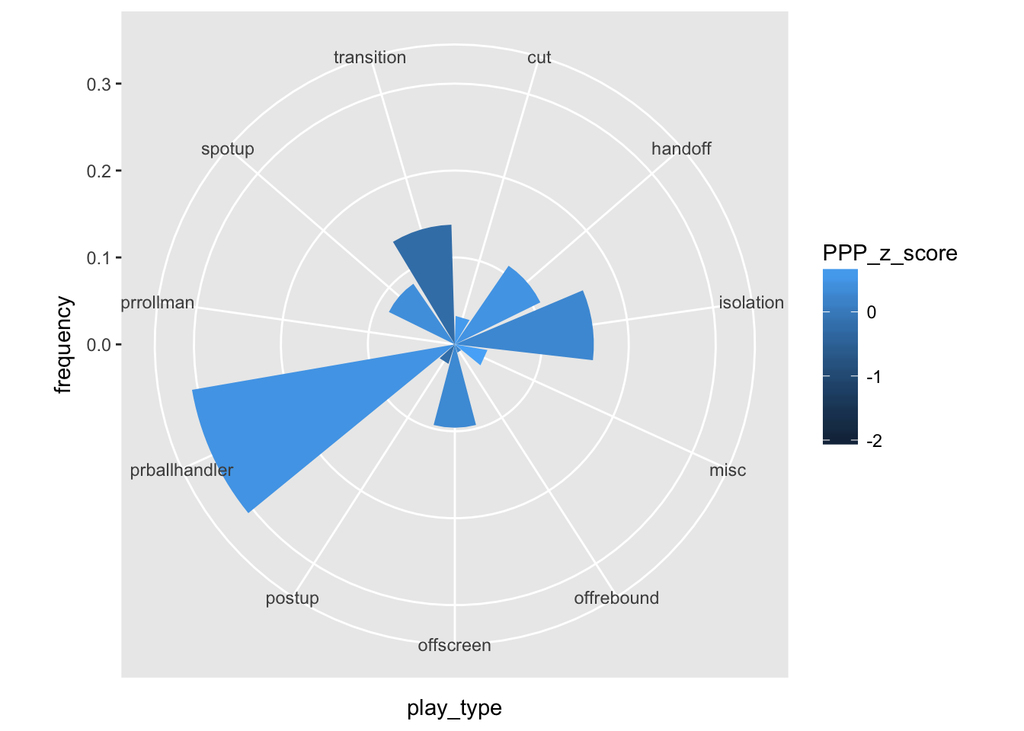

```r
rose_plot(player_stats[player_stats$PlayerLastName=="Irving",])
```

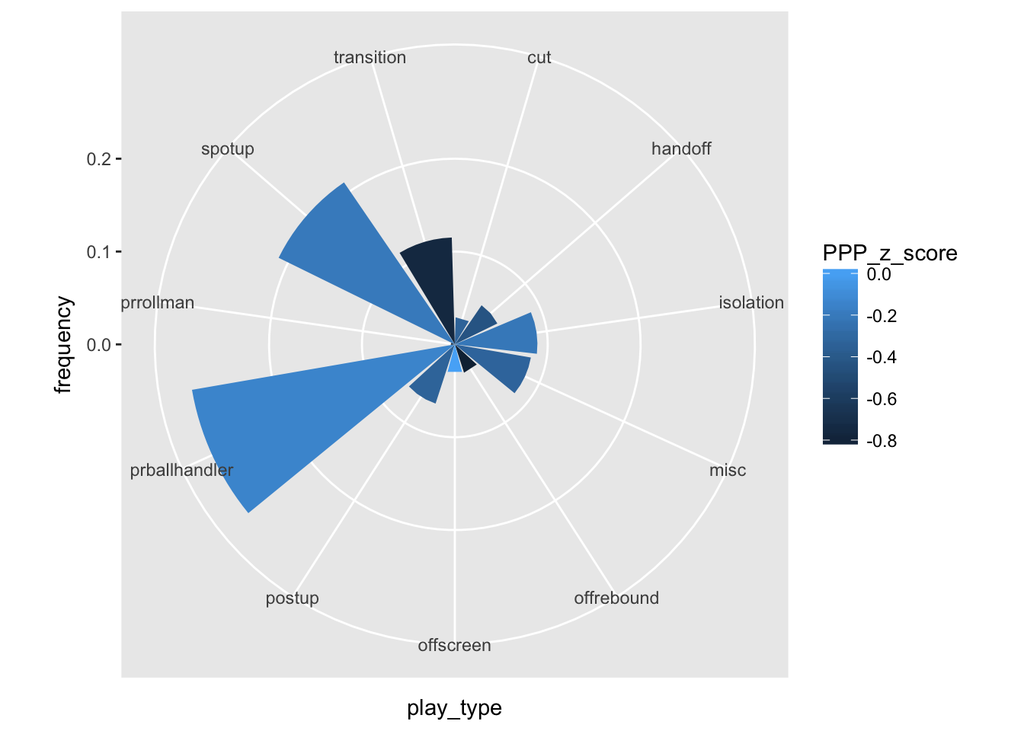

```r
rose_plot(player_stats[player_stats$PlayerLastName=="Smart",])
```

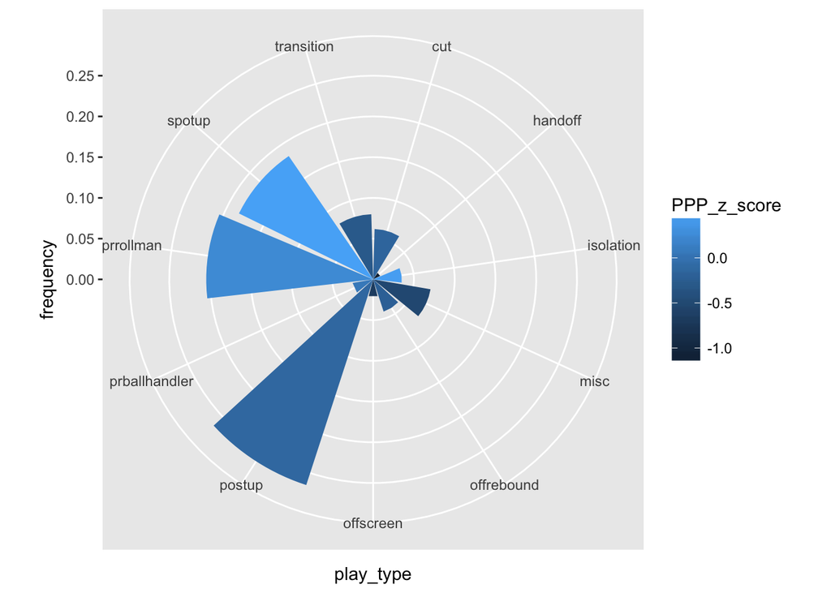

```r
rose_plot(player_stats[player_stats$PlayerLastName=="Horford",])
```

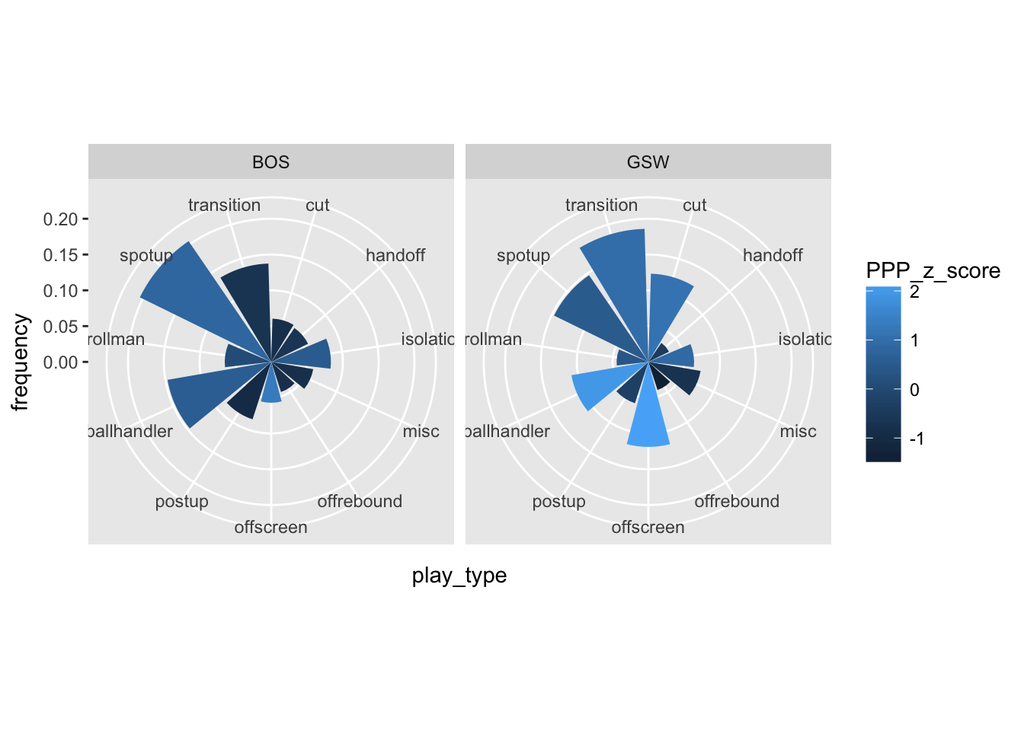

```r
bos_gsw_df <- team_stats %>%
  filter(TeamNameAbbreviation %in% c("BOS","GSW"))

  ggplot(
    bos_gsw_df,
    aes(x = play_type,
        y = frequency,
        fill = PPP_z_score
    )
  ) +
  geom_bar(stat = "identity") +
  coord_polar() +
  scale_fill_continuous() +
  facet_wrap(~TeamNameAbbreviation)
```